# ● Import the required libraries and load the data:

### 1.) Load the required libraries and read the dataset.

```python
# Importing libraries
import pandas as pd
import numpy as np
import matplotlib.pyplot as plt
import seaborn as sns
import warnings
warnings.filterwarnings('ignore')

from sklearn.preprocessing import StandardScaler,LabelEncoder
from sklearn.cluster import KMeans
from scipy.cluster.hierarchy import linkage, dendrogram, fcluster
from sklearn.cluster import AgglomerativeClustering
from sklearn.decomposition import PCA
from sklearn.preprocessing import Normalizer
from sklearn.metrics import silhouette_score
```

```python
# Reading the dataset
df = pd.read_csv("renttherunway.csv")

# Setting max columns to none
pd.set_option('display.max_columns', None)

df
```

|  | Unnamed: 0 | fit | user_id | bust size | item_id | weight | rating | rented for | review_text | body type | review_summary | category | height | size | age | review_date |
| --- | --- | --- | --- | --- | --- | --- | --- | --- | --- | --- | --- | --- | --- | --- | --- | --- |
| 0 | 0 | fit | 420272 | 34d | 2260466 | 137lbs | 10.0 | vacation | An adorable romper! Belt and zipper were a lit... | hourglass | So many compliments! | romper | 5' 8" | 14 | 28.0 | April 20, 2016 |
| 1 | 1 | fit | 273551 | 34b | 153475 | 132lbs | 10.0 | other | I rented this dress for a photo shoot. The the... | straight & narrow | I felt so glamourous!!! | gown | 5' 6" | 12 | 36.0 | June 18, 2013 |
| 2 | 2 | fit | 360448 | NaN | 1063761 | NaN | 10.0 | party | This hugged in all the right places! It was a ... | NaN | It was a great time to celebrate the (almost) ... | sheath | 5' 4" | 4 | 116.0 | December 14, 2015 |
| 3 | 3 | fit | 909926 | 34c | 126335 | 135lbs | 8.0 | formal affair | I rented this for my company's black tie award... | pear | Dress arrived on time and in perfect condition. | dress | 5' 5" | 8 | 34.0 | February 12, 2014 |
| 4 | 4 | fit | 151944 | 34b | 616682 | 145lbs | 10.0 | wedding | I have always been petite in my upper body and... | athletic | Was in love with this dress !!! | gown | 5' 9" | 12 | 27.0 | September 26, 2016 |
| ... | ... | ... | ... | ... | ... | ... | ... | ... | ... | ... | ... | ... | ... | ... | ... | ... |
| 192539 | 192539 | fit | 66386 | 34dd | 2252812 | 140lbs | 10.0 | work | Fit like a glove! | hourglass | LOVE IT!!! First Item Im thinking of buying! | jumpsuit | 5' 9" | 8 | 42.0 | May 18, 2016 |
| 192540 | 192540 | fit | 118398 | 32c | 682043 | 100lbs | 10.0 | work | The pattern contrast on this dress is really s... | petite | LOVE it! | dress | 5' 1" | 4 | 29.0 | September 30, 2016 |
| 192541 | 192541 | fit | 47002 | 36a | 683251 | 135lbs | 6.0 | everyday | Like the other DVF wraps, the fit on this is f... | straight & narrow | Loud patterning, flattering fit | dress | 5' 8" | 8 | 31.0 | March 4, 2016 |
| 192542 | 192542 | fit | 961120 | 36c | 126335 | 165lbs | 10.0 | wedding | This dress was PERFECTION. it looked incredib... | pear | loved this dress it was comfortable and photog... | dress | 5' 6" | 16 | 31.0 | November 25, 2015 |
| 192543 | 192543 | fit | 123612 | 36b | 127865 | 155lbs | 10.0 | wedding | This dress was wonderful! I had originally pla... | athletic | I wore this to a beautiful black tie optional ... | gown | 5' 6" | 16 | 30.0 | August 29, 2017 |

192544 rows × 16 columns

```python
# Dropping the 'Unnamed: 0' column because it likely represents an index or an artifact from reading data,
# and it doesn't provide any meaningful information for our analysis.
df.drop('Unnamed: 0',axis=1,inplace=True)
```

### 2.) Check the first few samples, shape, info of the data and try to familiarize yourself with different features

```python
## Checking first few samples
df.head(10)
```

|  | fit | user_id | bust size | item_id | weight | rating | rented for | review_text | body type | review_summary | category | height | size | age | review_date |
| --- | --- | --- | --- | --- | --- | --- | --- | --- | --- | --- | --- | --- | --- | --- | --- |
| 0 | fit | 420272 | 34d | 2260466 | 137lbs | 10.0 | vacation | An adorable romper! Belt and zipper were a lit... | hourglass | So many compliments! | romper | 5' 8" | 14 | 28.0 | April 20, 2016 |
| 1 | fit | 273551 | 34b | 153475 | 132lbs | 10.0 | other | I rented this dress for a photo shoot. The the... | straight & narrow | I felt so glamourous!!! | gown | 5' 6" | 12 | 36.0 | June 18, 2013 |
| 2 | fit | 360448 | NaN | 1063761 | NaN | 10.0 | party | This hugged in all the right places! It was a ... | NaN | It was a great time to celebrate the (almost) ... | sheath | 5' 4" | 4 | 116.0 | December 14, 2015 |
| 3 | fit | 909926 | 34c | 126335 | 135lbs | 8.0 | formal affair | I rented this for my company's black tie award... | pear | Dress arrived on time and in perfect condition. | dress | 5' 5" | 8 | 34.0 | February 12, 2014 |
| 4 | fit | 151944 | 34b | 616682 | 145lbs | 10.0 | wedding | I have always been petite in my upper body and... | athletic | Was in love with this dress !!! | gown | 5' 9" | 12 | 27.0 | September 26, 2016 |
| 5 | fit | 734848 | 32b | 364092 | 138lbs | 8.0 | date | Didn't actually wear it. It fit perfectly. The... | athletic | Traditional with a touch a sass | dress | 5' 8" | 8 | 45.0 | April 30, 2016 |
| 6 | fit | 336066 | 34c | 568429 | 112lbs | 10.0 | everyday | This dress is so sweet. I loved the print. The... | hourglass | LITERALLY THE CUTEST DRESS EVER | dress | 5' 3" | 4 | 27.0 | December 7, 2017 |
| 7 | fit | 86661 | 34d+ | 130259 | 118lbs | 10.0 | formal affair | Fit was great. Maybe a little tight under the ... | full bust | Great dress, beautifully made. I received lot... | dress | 5' 3" | 8 | 65.0 | January 1, 2013 |
| 8 | fit | 166228 | 36d | 1729232 | NaN | 10.0 | formal affair | I was nervous of it looking cheap when it arri... | full bust | Great for black tie event! | gown | 5' 6" | 21 | 27.0 | June 27, 2016 |
| 9 | fit | 154309 | 32b | 1729232 | 114lbs | 10.0 | formal affair | The dress was very flattering and fit perfectl... | petite | This dress was everything! It was perfect for ... | gown | 5' 3" | 1 | 33.0 | October 17, 2016 |

```python
# Checking the shape of the dataset to understand its dimensions.
df.shape
```

```
(192544, 15)
```

- The dataset contains 192,544 rows and 15 columns.

```python
# Checking info of the dataset
df.info()
```

```
<class 'pandas.core.frame.DataFrame'>
RangeIndex: 192544 entries, 0 to 192543
Data columns (total 15 columns):
 #   Column          Non-Null Count   Dtype
---  ------          --------------   -----
 0   fit             192544 non-null  object
 1   user_id         192544 non-null  int64
 2   bust size       174133 non-null  object
 3   item_id         192544 non-null  int64
 4   weight          162562 non-null  object
 5   rating          192462 non-null  float64
 6   rented for      192534 non-null  object
 7   review_text     192482 non-null  object
 8   body type       177907 non-null  object
 9   review_summary  192199 non-null  object
 10  category        192544 non-null  object
 11  height          191867 non-null  object
 12  size            192544 non-null  int64
 13  age             191584 non-null  float64
 14  review_date     192544 non-null  object
dtypes: float64(2), int64(3), object(10)
memory usage: 22.0+ MB
```

```python
# Checking the statistical summary of data
df.describe()
```

|  | user_id | item_id | rating | size | age |
| --- | --- | --- | --- | --- | --- |
| count | 192544.000000 | 1.925440e+05 | 192462.000000 | 192544.000000 | 191584.000000 |
| mean | 499494.100149 | 1.045684e+06 | 9.092371 | 12.245175 | 33.871017 |
| std | 289059.719328 | 8.053148e+05 | 1.430044 | 8.494877 | 8.058083 |
| min | 9.000000 | 1.233730e+05 | 2.000000 | 0.000000 | 0.000000 |
| 25% | 250654.250000 | 1.950760e+05 | 8.000000 | 8.000000 | 29.000000 |
| 50% | 499419.000000 | 9.483960e+05 | 10.000000 | 12.000000 | 32.000000 |
| 75% | 750974.000000 | 1.678888e+06 | 10.000000 | 16.000000 | 37.000000 |
| max | 999997.000000 | 2.966087e+06 | 10.000000 | 58.000000 | 117.000000 |

```python
# Checking the statistical summary of data -- for object type
df.describe(include = 'O')
```

|  | fit | bust size | weight | rented for | review_text | body type | review_summary | category | height | review_date |
| --- | --- | --- | --- | --- | --- | --- | --- | --- | --- | --- |
| count | 192544 | 174133 | 162562 | 192534 | 192482 | 177907 | 192199 | 192544 | 191867 | 192544 |
| unique | 3 | 106 | 190 | 9 | 191027 | 7 | 154736 | 68 | 24 | 2274 |
| top | fit | 34b | 130lbs | wedding | . | hourglass | Stylist Review | dress | 5' 4" | June 15, 2016 |
| freq | 142058 | 27285 | 14370 | 57784 | 63 | 55349 | 977 | 92884 | 28012 | 844 |

```python
# Percentage of null values in a specific column of the dataset
df.isnull().sum()/len(df) * 100
```

```
fit                0.000000
user_id            0.000000
bust size          9.561970
item_id            0.000000
weight            15.571506
rating             0.042588
rented for         0.005194
review_text        0.032200
body type          7.601899
review_summary     0.179180
category           0.000000
height             0.351608
size               0.000000
age                0.498587
review_date        0.000000
dtype: float64
```

#### observations:

- The dataset contains 192,544 entries with 15 columns.
- The majority of columns have non-null values, but some columns such as 'bust size', 'weight', 'body type', 'review_text', 'review_summary', 'height', 'age', and 'rating' have missing values.
- Data types include integers, floats, and objects (likely representing strings).
- Columns such as 'fit', 'rented for', 'body type', 'category', and 'review_date' are categorical, while others like 'rating', 'size', and 'age' are numerical.
- Further data cleaning and preprocessing may be necessary, particularly handling missing values in certain columns before proceeding with analysis or modeling tasks.

# ● Data cleansing and Exploratory data analysis

### 3.) Check if there are any duplicate records in the dataset? If any, drop them.

```python
len(df[df.duplicated()])
```

```
189
```

- We have identified 189 duplicate records in the DataFrame. To ensure the integrity of our analysis, it is essential to remove these duplicates.

```python
# Dropping the duplicated record from the dataset
df.drop_duplicates(inplace=True)
```

```python
# Recheck the presence of the duplicate record
len(df[df.duplicated()])
```

```
0
```

### 4.) Drop the columns which you think redundant for the analysis.(Hint: drop columns like ‘id’, ‘review’)

```python
# Checking various columns present in the dataset
df.columns
```

```
Index(['fit', 'user_id', 'bust size', 'item_id', 'weight', 'rating',
       'rented for', 'review_text', 'body type', 'review_summary', 'category',
       'height', 'size', 'age', 'review_date'],
      dtype='object')
```

```python
# Dropping redundant columns that are not required for analysis
df=df.drop(['user_id', 'item_id','review_text', 'review_summary','review_date'],axis=1)
```

```python
# Checking the shape of the DataFrame after dropping columns
df.shape
```

```
(192355, 10)
```

- After dropping the redundant columns, dataset has 192355 rows and 10 columns.

### 5.) Check the column 'weight', Is there any presence of string data? If yes, remove the string data and convert to float. (Hint: 'weight' has the suffix as lbs)

```python
# Displaying a sample of records from the 'weight' column
df[['weight']].head()
```

|  | weight |
| --- | --- |
| 0 | 137lbs |
| 1 | 132lbs |
| 2 | NaN |
| 3 | 135lbs |
| 4 | 145lbs |

```python
# Checking null values in column "weight"
print('Total entries with null values in column "weight": ', df.weight.isnull().sum())
```

```
Total entries with null values in column "weight":  29955
```

```python
# Removing 'lbs' from column "weight" and converting it to float type
df['weight'] = [float(x.strip('lbs')) if isinstance(x, str) else x for x in df['weight']]
```

```python
# Renaming the 'weight' column to 'weight (in lbs)' for enhanced dataset comprehension.
df.rename(columns={'weight': 'weight (in lbs)'}, inplace=True)
```

```python
# Displaying a sample of records from the 'weight (in lbs)' column
df[['weight (in lbs)']].head()
```

|  | weight (in lbs) |
| --- | --- |
| 0 | 137.0 |
| 1 | 132.0 |
| 2 | NaN |
| 3 | 135.0 |
| 4 | 145.0 |

- NaN (Not a Number) these null/missing values will be treated later.

```python
#Checking the datatype of 'weight'
df['weight (in lbs)'].dtype
```

```
dtype('float64')
```

### Inferences:

- Initial data exploration highlights the existence of null values in the weight column, necessitating further treatment. However, we will address this issue at a later stage in our analysis.
- Subsequently, the 'lbs' suffix is removed from weight entries and the values are converted to float, aligning with the specified requirement.
- The 'weight' column has been renamed to 'weight (in lbs)' to improve clarity and facilitate better understanding of the dataset.

### 6.) Check the unique categories for the column 'rented for' and group 'party: cocktail' category with 'party'.

```python
# Checking unique categories in the column 'rented for':
df['rented for'].unique()
```

```
array(['vacation', 'other', 'party', 'formal affair', 'wedding', 'date',
       'everyday', 'work', nan, 'party: cocktail'], dtype=object)
```

```python
# Grouping 'party: cocktail' category with the 'party'.
df['rented for'] = df['rented for'].replace({'party: cocktail':'party'})
```

```python
# Rechecking unique values after grouping
df['rented for'].unique()
```

```
array(['vacation', 'other', 'party', 'formal affair', 'wedding', 'date',
       'everyday', 'work', nan], dtype=object)
```

### 7.) The column 'height' is in feet with a quotation mark, Convert to inches with float datatype

```python
# Checking first few records before conversion:
df[['height']].head()
```

|  | height |
| --- | --- |
| 0 | 5' 8" |
| 1 | 5' 6" |
| 2 | 5' 4" |
| 3 | 5' 5" |
| 4 | 5' 9" |

```python
# Converting height from feet to inches and changing the datatype to float.
df['height'] = df['height'].apply(lambda x: np.nan if pd.isna(x)
                                  else (float(x.split("'")[0]) * 12 + float(x.split("'")[1].strip('"'))))
```

```python
# Renaming the 'height' column to 'height (in inches)' for enhanced dataset comprehension.
df.rename(columns={'height': 'height (in inches)'}, inplace=True)
```

```python
# Checking first few records after conversion:
df[['height (in inches)']].head()
```

|  | height (in inches) |
| --- | --- |
| 0 | 68.0 |
| 1 | 66.0 |
| 2 | 64.0 |
| 3 | 65.0 |
| 4 | 69.0 |

### Inference:

- The "Height" column has been converted to a Float datatype, now represented as dtype: float64.
- The quotation marks have been removed, signifying that the height values are now expressed in inches rather than feet.
- The 'height' column has been renamed to 'height (in inches)' to improve clarity and facilitate better understanding of the dataset.

### 8.) Check for missing values in each column of the dataset? If it exists, impute them with appropriate methods.

```python
# Calculating the percentage of missing values for each column in the DataFrame.
df.isnull().sum()/len(df) * 100
```

```
fit                    0.000000
bust size              9.561488
weight (in lbs)       15.572769
rating                 0.042110
rented for             0.005199
body type              7.603130
category               0.000000
height (in inches)     0.350914
size                   0.000000
age                    0.499077
dtype: float64
```

- Most columns show negligible missing values with percentages ranging from **0% to 1%**.
- However, the columns **'weight (in lbs)', 'bust size' and 'body type'** exhibit slightly higher percentages of missing values, ranging from approximately **7.6% to 15.5%**.
- **Median** imputation will be applied for numerical columns, while **mode** imputation will be utilized for categorical columns.

```python
# Selecting object (categorical) columns
categorical_columns = df.select_dtypes(include=['object']).columns

# Selecting non-object (numerical) columns
numerical_columns = df.select_dtypes(exclude=['object']).columns

# Imputing missing values with median for numerical columns
for column in numerical_columns:
    df[column] = df[column].fillna(df[column].median())

# Imputing missing values with mode for categorical columns
for column in categorical_columns:
    df[column] = df[column].fillna(df[column].mode().iloc[0])
```

```python
# Calculating the percentage of missing values for each column in the DataFrame after imputation
df.isnull().sum()/len(df) * 100
```

```
fit                   0.0
bust size             0.0
weight (in lbs)       0.0
rating                0.0
rented for            0.0
body type             0.0
category              0.0
height (in inches)    0.0
size                  0.0
age                   0.0
dtype: float64
```

### 9.) Check the statistical summary for the numerical and categorical columns and write your findings.

```python
# Checking statistical summary for numerical columns
df.describe()
```

|  | weight (in lbs) | rating | height (in inches) | size | age |
| --- | --- | --- | --- | --- | --- |
| count | 192355.000000 | 192355.000000 | 192355.000000 | 192355.000000 | 192355.000000 |
| mean | 137.019875 | 9.092709 | 65.309334 | 12.245801 | 33.860633 |
| std | 20.143567 | 1.429922 | 2.658946 | 8.496299 | 8.039386 |
| min | 50.000000 | 2.000000 | 54.000000 | 0.000000 | 0.000000 |
| 25% | 125.000000 | 8.000000 | 63.000000 | 8.000000 | 29.000000 |
| 50% | 135.000000 | 10.000000 | 65.000000 | 12.000000 | 32.000000 |
| 75% | 145.000000 | 10.000000 | 67.000000 | 16.000000 | 37.000000 |
| max | 300.000000 | 10.000000 | 78.000000 | 58.000000 | 117.000000 |

```python
# Checking statistical summary for categorical columns
df.describe(include='O')
```

|  | fit | bust size | rented for | body type | category |
| --- | --- | --- | --- | --- | --- |
| count | 192355 | 192355 | 192355 | 192355 | 192355 |
| unique | 3 | 106 | 8 | 7 | 68 |
| top | fit | 34b | wedding | hourglass | dress |
| freq | 141909 | 45647 | 57747 | 69915 | 92752 |

### Findings:

#### Numerical Columns:

- The dataset comprises 5 numerical columns, each providing valuable insights into customer characteristics and preferences.
- The presence of minimum values of 0 across various numerical columns suggests potential data anomalies or outliers that warrant further investigation.
- Maximum values in the dataset represent the upper limits of the respective column ranges, providing context for understanding the scale and variability of numerical data.
- The dataset reveals that the average weight of customers is approximately 137 lbs.
- Customers, on average, give a rating of around 9, indicating a high level of satisfaction.
- Regarding height, customers vary from a minimum of 54 inches to a maximum of 78 inches.
- The wide age range observed, extending up to 117 years, there could be possibilities of outliers in 'age' column.

#### Categorical Columns:

- Among the 5 object type columns, 'fit' provides insights into customer satisfaction levels regarding product sizes, with the majority of items reported to fit well.
- 'Body type', 'category', and 'rented for' offer valuable information on customer preferences and popular product categories, such as 'hourglass' being the dominant body type and 'dress' being the most rented category.
- Understanding frequent occurrences in these categorical columns enables businesses to tailor inventory management and marketing strategies to meet customer demands effectively, thereby enhancing customer satisfaction and loyalty.
- **In summary:** a comprehensive analysis of both numerical and categorical columns allows businesses to gain deeper insights into customer demographics, preferences, and satisfaction levels, facilitating informed decision-making and strategic planning in the e-commerce domain.

### 10.) Are there outliers present in the column age? If yes, treat them with the appropriate method.

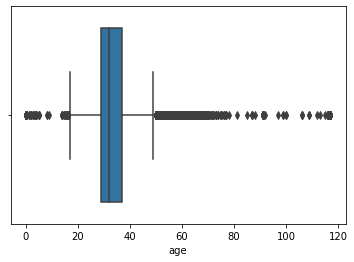

```python
# Plotting the box-plot of 'age'
sns.boxplot(df['age'])
```

- Observing the boxplot reveals the presence of outliers in the 'age' column. To address these outliers, we will utilize the Interquartile Range (IQR) method.

```python
# IQR treatment for outliers:

Q1 = df['age'].quantile(0.25)
Q2 = df['age'].quantile(0.5)
Q3 = df['age'].quantile(0.75)

IQR = Q3 - Q1

lower_range = Q1 - (1.5*IQR)
upper_range = Q3 + (1.5*IQR)

df = df.loc[(df['age'] > lower_range) & (df['age'] < upper_range)]
```

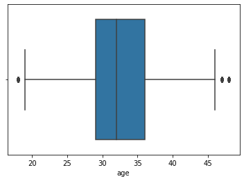

```python
# Plotting boxplot after IQR treatment:
sns.boxplot(df['age'])
```

```python
# Checking the shape of the dataset after handling the outliers.
df.shape
```

```
(180531, 10)
```

### Inference:

- The boxplot visualization of the 'age' column indicates the presence of numerous outliers. To address this, an Interquartile Range (IQR) treatment method is applied, which effectively reduces the impact of outliers.
- After outlier treatment using the IQR method, the dataset was refined from 192355 to 180531 records. This refinement ensures a more balanced distribution of the 'age' data, making the dataset more reliable and suitable for further analysis, modeling, or visualization tasks.

### 11.) Check the distribution of the different categories in the column 'rented for' using appropriate plot.

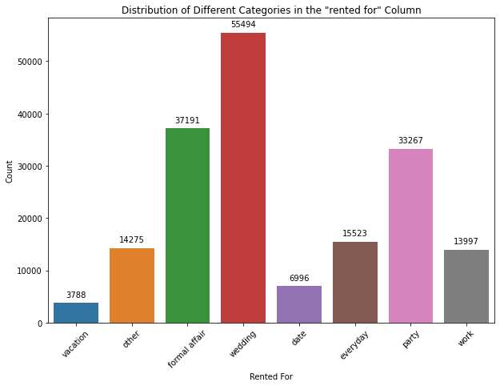

```python
# Plotting the distribution of different categories in the 'rented for' column
plt.figure(figsize=(10, 7))
ax = sns.countplot(data=df, x='rented for')
plt.title('Distribution of Different Categories in the "rented for" Column')
plt.xlabel('Rented For')
plt.ylabel('Count')
plt.xticks(rotation=45)

# Annotating each count bar with its respective count
for p in ax.patches:
    ax.annotate(f'{p.get_height()}', (p.get_x() + p.get_width() / 2., p.get_height()), ha='center', va='center', xytext=(0, 10), textcoords='offset points')

plt.show()
```

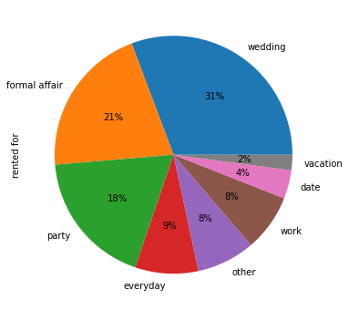

```python
# Creating a pie chart to visualize the distribution of categories in the 'rented for' column
plt.figure(figsize=(10, 6))
df['rented for'].value_counts().plot(kind='pie',autopct='%1.0f%%')
plt.show()
```

### Inference:

- The above plots depict the distribution of categories for which outfits are rented within the dataset.
- The most prevalent purpose for renting outfits is **'wedding'**, accounting for **55494 (approximately 55,500) entries**, which equates to roughly **31%** of the total categories.
- Following 'weddings', the next most common purposes are **'formal affair' and 'party'**.
- On the contrary, the purposes **'vacation'** and **'date'** are significantly less popular, with only **3788 and 6996 entries**, respectively. These figures represent approximately **2% and 4%** of the total entries in the dataset, indicating a much lower frequency compared to other categories such as 'weddings', 'formal affairs', and 'parties'.

# ● Data Preparation for model building:

### 12.) Encode the categorical variables in the dataset

```python
# Keeping a copy of the cleaned dataset.
df_cleaned = df.copy()
```

```python
# Selecting columns with object datatype
df.select_dtypes('object').columns
```

```
Index(['fit', 'bust size', 'rented for', 'body type', 'category'], dtype='object')
```

```python
# Iterating through each column with object datatype and applying label encoding
for col in df.select_dtypes('object').columns:
    # Initializing a new LabelEncoder object for each column
    le = LabelEncoder()
    # Fit-transforming the column and replacing the original values with encoded labels
    df[col] = le.fit_transform(df[col])
```

```python
# Displaying the first few records of the DataFrame df1 after applying label encoding to categorical variables
df.head()
```

|  | fit | bust size | weight (in lbs) | rating | rented for | body type | category | height (in inches) | size | age |
| --- | --- | --- | --- | --- | --- | --- | --- | --- | --- | --- |
| 0 | 0 | 39 | 137.0 | 10.0 | 5 | 3 | 44 | 68.0 | 14 | 28.0 |
| 1 | 0 | 37 | 132.0 | 10.0 | 3 | 6 | 20 | 66.0 | 12 | 36.0 |
| 3 | 0 | 38 | 135.0 | 8.0 | 2 | 4 | 16 | 65.0 | 8 | 34.0 |
| 4 | 0 | 37 | 145.0 | 10.0 | 6 | 1 | 20 | 69.0 | 12 | 27.0 |
| 5 | 0 | 24 | 138.0 | 8.0 | 0 | 1 | 16 | 68.0 | 8 | 45.0 |

- All categorical columns have been successfully encoded using the LabelEncoder technique, resulting in their conversion to numerical type.

### 13.) Standardize the data, so that the values are within a particular range.

```python
df1 = df.copy()
```

```python
# Initialize the StandardScaler object
ss = StandardScaler()

# Fit and transform the data
scaled_features = ss.fit_transform(df1)

# Convert the scaled array back to a DataFrame
scaled_features_df = pd.DataFrame(scaled_features, index=df1.index, columns= df1.columns)

# Checking some samples from scaled_features_df
scaled_features_df.head(5)
```

|  | fit | bust size | weight (in lbs) | rating | rented for | body type | category | height (in inches) | size | age |
| --- | --- | --- | --- | --- | --- | --- | --- | --- | --- | --- |
| 0 | -0.556782 | 0.019717 | 0.005575 | 0.636126 | 0.502733 | 0.016789 | 1.578749 | 1.008246 | 0.233626 | -0.769957 |
| 1 | -0.556782 | -0.164502 | -0.243996 | 0.636126 | -0.468085 | 1.926202 | -0.304798 | 0.258112 | -0.004654 | 0.585645 |
| 3 | -0.556782 | -0.072393 | -0.094253 | -0.766009 | -0.953494 | 0.653260 | -0.618723 | -0.116955 | -0.481213 | 0.246745 |
| 4 | -0.556782 | -0.164502 | 0.404890 | 0.636126 | 0.988142 | -1.256154 | -0.304798 | 1.383314 | -0.004654 | -0.939407 |
| 5 | -0.556782 | -1.361931 | 0.055490 | -0.766009 | -1.924313 | -1.256154 | -0.618723 | 1.008246 | -0.481213 | 2.110698 |

- The dataset has been standardized using the Standard Scaler technique, ensuring that all columns are scaled to a particular range. This standardization enables consistent computation and analysis across the dataset.

# ● Principal Component Analysis and Clustering:

### 14.) Apply PCA on the above dataset and determine the number of PCA components to be used so that 90-95% of the variance in data is explained by the same.

```python
## Step1: Calculate the Covariance Matrix
cov_matrix = np.cov(scaled_features.T)
print('Covariance matrix','\n',cov_matrix)
```

```
Covariance matrix
 [[ 1.00000554e+00  8.85382387e-03  1.47179578e-02 -2.43976724e-01
   7.51853608e-03 -8.17094537e-03  2.92230406e-04  1.41966736e-04
   6.57803423e-02 -1.81644662e-03]
 [ 8.85382387e-03  1.00000554e+00  5.68054989e-01 -2.09808478e-02
   5.85676356e-04 -2.17280915e-01 -1.29132056e-02  1.48479410e-01
   6.26687911e-01  1.47335159e-01]
 [ 1.47179578e-02  5.68054989e-01  1.00000554e+00 -2.13609762e-02
   9.82928796e-03 -2.37264407e-01 -1.75365753e-02  3.51571202e-01
   7.22089712e-01  6.91620017e-02]
 [-2.43976724e-01 -2.09808478e-02 -2.13609762e-02  1.00000554e+00
   1.25426644e-02  5.19818763e-03 -2.40478681e-02  1.18467962e-03
  -3.78392329e-02 -5.02524467e-02]
 [ 7.51853608e-03  5.85676356e-04  9.82928796e-03  1.25426644e-02
   1.00000554e+00 -1.12759624e-02 -5.87182956e-02 -1.73982232e-02
   6.60761996e-03 -1.83755128e-02]
 [-8.17094537e-03 -2.17280915e-01 -2.37264407e-01  5.19818763e-03
  -1.12759624e-02  1.00000554e+00 -2.01534595e-03 -1.35661479e-01
  -2.16199683e-01 -4.64856865e-02]
 [ 2.92230406e-04 -1.29132056e-02 -1.75365753e-02 -2.40478681e-02
  -5.87182956e-02 -2.01534595e-03  1.00000554e+00 -5.21877028e-03
  -8.67091257e-03  2.19753778e-02]
 [ 1.41966736e-04  1.48479410e-01  3.51571202e-01  1.18467962e-03
  -1.73982232e-02 -1.35661479e-01 -5.21877028e-03  1.00000554e+00
   2.33082719e-01 -2.14980241e-03]
 [ 6.57803423e-02  6.26687911e-01  7.22089712e-01 -3.78392329e-02
   6.60761996e-03 -2.16199683e-01 -8.67091257e-03  2.33082719e-01
   1.00000554e+00  1.30061056e-01]
 [-1.81644662e-03  1.47335159e-01  6.91620017e-02 -5.02524467e-02
  -1.83755128e-02 -4.64856865e-02  2.19753778e-02 -2.14980241e-03
   1.30061056e-01  1.00000554e+00]]
```

```python
## Step2: Calculate the Eigen values and Eigen vectors
eig_vals, eig_vectors = np.linalg.eig(cov_matrix)
print('Eigen vectors:','\n',eig_vectors)
print('\n')
print('Eigen values:','\n',eig_vals)
```

```
Eigen vectors:
 [[-0.03841136 -0.0518874   0.03696811 -0.68366233 -0.68374906  0.18178638
   0.12996611  0.0958963  -0.01730167 -0.01121361]
 [-0.49555814 -0.11879544  0.78415133  0.02051602  0.05195457 -0.04340195
  -0.17410381  0.23272473 -0.18742307 -0.0284994 ]
 [-0.54450001 -0.66798932 -0.46570875  0.05116904  0.03588348  0.04366151
   0.08406834 -0.00748673 -0.16522255 -0.01382422]
 [ 0.03810833 -0.00598031 -0.00158885  0.70134972 -0.69990342 -0.02886377
  -0.02765953  0.10593484 -0.05981102  0.01885547]
 [-0.0035786   0.00376476  0.01594884  0.04310543  0.02630685  0.63390469
  -0.33957707 -0.18944215 -0.08134665  0.6614493 ]
 [ 0.25727748 -0.02088759  0.02560182 -0.04567268 -0.01064743 -0.02146323
  -0.08939928 -0.34093474 -0.86888505 -0.22553619]
 [ 0.01169797 -0.0073344   0.00441961 -0.09518689 -0.04162226 -0.64050161
   0.21049445  0.0026137  -0.18140237  0.70818995]
 [-0.27548667  0.10951287  0.22170989  0.09645008 -0.07113689  0.07607407
   0.50046548 -0.75137626  0.16523496 -0.021768  ]
 [-0.54499104  0.72296203 -0.33547981 -0.01689937 -0.01350801  0.00194023
  -0.05852514  0.11832566 -0.22215295 -0.02267295]
 [-0.12555758 -0.04217132 -0.06497356 -0.12281037 -0.17565529 -0.37947512
  -0.72350572 -0.44120965  0.25011508 -0.08725105]]


Eigen values:
 [2.54864858 0.25952724 0.41760172 1.24922751 0.74926837 1.07087105
 1.01707486 0.85344244 0.89064147 0.94375215]
```

```python
## Step3: Calculating the Variance explained and the cummulative variance explained
total = sum(eig_vals)
var_exp = [(i/total)*100 for i in sorted(eig_vals, reverse = True)]
cum_var_exp = np.cumsum(var_exp)
print('Explained Variance: ',var_exp)
print('\n')
print('Cummulative Variance Explained: ',cum_var_exp)
```

```
Explained Variance:  [25.486344621477947, 12.492205876030527, 10.708651167610473, 10.170692309222503, 9.437469265414515, 8.906365340911583, 8.53437714752482, 7.492642188703866, 4.175994020770695, 2.5952580623330648]


Cummulative Variance Explained:  [ 25.48634462  37.9785505   48.68720167  58.85789397  68.29536324
  77.20172858  85.73610573  93.22874792  97.40474194 100.        ]
```

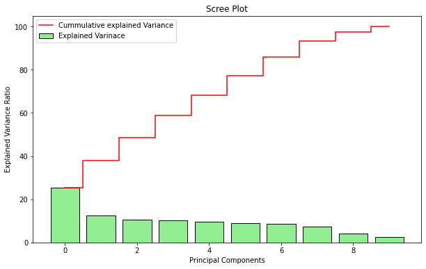

```python
## Step4: Scree plot
plt.figure(figsize=(10, 6))
plt.bar(range(10),var_exp, align='center',color='lightgreen',edgecolor='black',label='Explained Varinace')
plt.step(range(10), cum_var_exp, where='mid',color='red',label='Cummulative explained Variance')
plt.legend(loc = 'best')
plt.title('Scree Plot')
plt.xlabel('Principal Components')
plt.ylabel('Explained Variance Ratio')
plt.show()
```

- Based on the scree plot analysis, we notice that the first 8 principal components collectively explain approximately 90-95% of the variation in the data. Therefore, we can consider 8 as the optimal number of principal components

### 15.) Apply K-means clustering and segment the data. (You may use original data or PCA transformed data).

a. Find the optimal K Value using elbow plot for K Means clustering. b. Build a Kmeans clustering model using the obtained optimal K value from the elbow plot. c. Compute silhouette score for evaluating the quality of the K Means clustering technique.

#### a. Find the optimal K Value using elbow plot for K Means clustering.

```python
# Performing Principal Component Analysis (PCA) with 8 components
pca = PCA(n_components=8)

# Transforming the standardized features using PCA and creating a DataFrame with the transformed components
pca_df = pd.DataFrame(pca.fit_transform(scaled_features_df), columns=['PC1', 'PC2', 'PC3', 'PC4', 'PC5', 'PC6', 'PC7', 'PC8'])

# Displaying the first few records of the DataFrame containing the PCA components
pca_df.head()
```

|  | PC1 | PC2 | PC3 | PC4 | PC5 | PC6 | PC7 | PC8 |
| --- | --- | --- | --- | --- | --- | --- | --- | --- |
| 0 | 0.254599 | -0.885970 | 0.443721 | 1.115166 | 1.504334 | 0.452784 | -0.468511 | -0.055600 |
| 1 | -0.611581 | -0.684848 | 0.468541 | -0.453507 | -0.990210 | 1.347387 | -1.044176 | -0.223136 |
| 2 | -0.507130 | 0.208391 | 0.405696 | -0.120239 | -1.229101 | 0.143924 | -0.272315 | 0.874879 |
| 3 | 0.684194 | -1.221987 | -1.215521 | 1.057551 | 0.790346 | -0.996529 | -0.412511 | 0.060181 |
| 4 | -0.032850 | 0.302211 | 1.539338 | -0.168226 | -1.593051 | -2.463183 | -1.406488 | 0.400590 |

```python
# a. Finding the optimal K Value using elbow plot for K Means clustering.
cluster_errors = []
cluster_range = range(2,15)

for num_clusters in cluster_range:
    cluster = KMeans(num_clusters, random_state=100)
    cluster.fit(pca_df)
    cluster_errors.append(cluster.inertia_)

# Creataing a dataframe of number of clusters and cluster errors.
cluster_df = pd.DataFrame({'num_clusters': cluster_range, 'cluster_errors': cluster_errors})
cluster_df
```

|  | num_clusters | cluster_errors |
| --- | --- | --- |
| 0 | 2 | 1.402898e+06 |
| 1 | 3 | 1.273782e+06 |
| 2 | 4 | 1.170838e+06 |
| 3 | 5 | 1.082117e+06 |
| 4 | 6 | 1.026599e+06 |
| 5 | 7 | 9.776973e+05 |
| 6 | 8 | 9.325028e+05 |
| 7 | 9 | 9.020995e+05 |
| 8 | 10 | 8.746032e+05 |
| 9 | 11 | 8.548164e+05 |
| 10 | 12 | 8.290871e+05 |
| 11 | 13 | 8.120514e+05 |
| 12 | 14 | 7.923838e+05 |

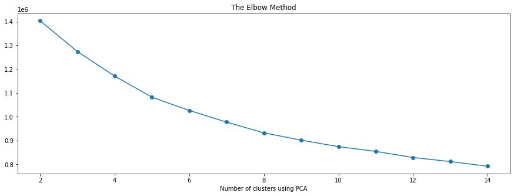

```python
# Elbow plot:
plt.figure(figsize=[15,5])
plt.title('The Elbow Method')
plt.xlabel('Number of clusters using PCA')
plt.plot(cluster_df['num_clusters'], cluster_df['cluster_errors'], marker='o')
```

- Upon examining the plot, we can see a distinct bend or elbow around the 4th or 5th cluster. After that point, the decrease in inertia becomes less significant as we increase the number of clusters further.
- Therefore, based on the elbow method and the visualized plot, the optimal K value or the recommended number of clusters would be either 4 or 5.
- So, we are taking K=5 as the optimal number of clusters for our dataset. The clusters are labeled as 0,1,2,3,4.

#### b. Build a Kmeans clustering model using the obtained optimal K value from the elbow plot.

```python
# Applying KMeans clustering for the optimal number of clusters obtained above.
kmeans = KMeans(n_clusters=5, random_state=100)
kmeans.fit(pca_df)
```

```
KMeans(n_clusters=5, random_state=100)
```

```python
# Checking the cluster labels
label = pd.DataFrame(kmeans.labels_, columns=['Label'])
kmeans_df = pca_df.join(label)
kmeans_df.head()
```

|  | PC1 | PC2 | PC3 | PC4 | PC5 | PC6 | PC7 | PC8 | Label |
| --- | --- | --- | --- | --- | --- | --- | --- | --- | --- |
| 0 | 0.254599 | -0.885970 | 0.443721 | 1.115166 | 1.504334 | 0.452784 | -0.468511 | -0.055600 | 3 |
| 1 | -0.611581 | -0.684848 | 0.468541 | -0.453507 | -0.990210 | 1.347387 | -1.044176 | -0.223136 | 2 |
| 2 | -0.507130 | 0.208391 | 0.405696 | -0.120239 | -1.229101 | 0.143924 | -0.272315 | 0.874879 | 1 |
| 3 | 0.684194 | -1.221987 | -1.215521 | 1.057551 | 0.790346 | -0.996529 | -0.412511 | 0.060181 | 1 |
| 4 | -0.032850 | 0.302211 | 1.539338 | -0.168226 | -1.593051 | -2.463183 | -1.406488 | 0.400590 | 1 |

```python
# Counting the number of data points assigned to each cluster label
kmeans_df['Label'].value_counts()
```

```
1    62077
2    37458
0    28277
4    27470
3    25249
Name: Label, dtype: int64
```

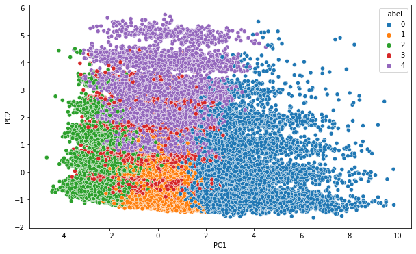

```python
## Visualizing the clusters formed
plt.figure(figsize=(10, 6))
sns.scatterplot(data=kmeans_df, x='PC1', y='PC2', hue='Label', palette='tab10')
plt.show()
```

#### c. Compute silhouette score for evaluating the quality of the K Means clustering technique.

```python
#Taking a sample of 20k records from the dataset to reduce the computational time.
pca_df_20k = pca_df.sample(20000)
```

```python
## finding optimal clusters through silhoutte score
print("Cluster --> Silhouette Score")
for i in range(2,15):
    kmeans = KMeans(i,random_state=100)
    kmeans.fit(pca_df_20k)
    labels = kmeans.predict(pca_df_20k)
    print(i, "      =>  ", silhouette_score(pca_df_20k,labels))
```

```
Cluster --> Silhouette Score
2       =>   0.15718476020406477
3       =>   0.15771790103272657
4       =>   0.12686103041755786
5       =>   0.13351449332775434
6       =>   0.12133505452681716
7       =>   0.12813161429229816
8       =>   0.12539158046117688
9       =>   0.1291868783173353
10       =>   0.11775605152992502
11       =>   0.11562847712654052
12       =>   0.120435896360925
13       =>   0.12337435111632163
14       =>   0.11367758574659956
```

- Based on the silhouette scores, the optimal value of K seems to be 3, as it has the highest silhouette score among the tested values.

### Inference:

- Based on the elbow plot analysis, we initially selected the optimal K value as 5, as there was a noticeable bend or change in inertia around that point.
- However, considering the silhouette scores, we find that for K=3, the silhouette score is the highest among the tested values.
- Hence, we have two potential optimal K values: 3 or 5, depending on whether we prioritize the elbow method or silhouette score.

### 16.) Apply Agglomerative clustering and segment the data. (You may use original data or PCA transformed data)

### a. Find the optimal K Value using dendrogram for Agglomerative clustering.

- To reduce computational time, we are sampling 5,000 rows from the original scaled data ('scaled_features_df') and creating a new DataFrame 'df2'.
- This sampled data will be used for Agglomerative clustering analysis.

```python
df2 = scaled_features_df.head(5000)
df2.head()
```

|  | fit | bust size | weight (in lbs) | rating | rented for | body type | category | height (in inches) | size | age |
| --- | --- | --- | --- | --- | --- | --- | --- | --- | --- | --- |
| 0 | -0.556782 | 0.019717 | 0.005575 | 0.636126 | 0.502733 | 0.016789 | 1.578749 | 1.008246 | 0.233626 | -0.769957 |
| 1 | -0.556782 | -0.164502 | -0.243996 | 0.636126 | -0.468085 | 1.926202 | -0.304798 | 0.258112 | -0.004654 | 0.585645 |
| 3 | -0.556782 | -0.072393 | -0.094253 | -0.766009 | -0.953494 | 0.653260 | -0.618723 | -0.116955 | -0.481213 | 0.246745 |
| 4 | -0.556782 | -0.164502 | 0.404890 | 0.636126 | 0.988142 | -1.256154 | -0.304798 | 1.383314 | -0.004654 | -0.939407 |
| 5 | -0.556782 | -1.361931 | 0.055490 | -0.766009 | -1.924313 | -1.256154 | -0.618723 | 1.008246 | -0.481213 | 2.110698 |

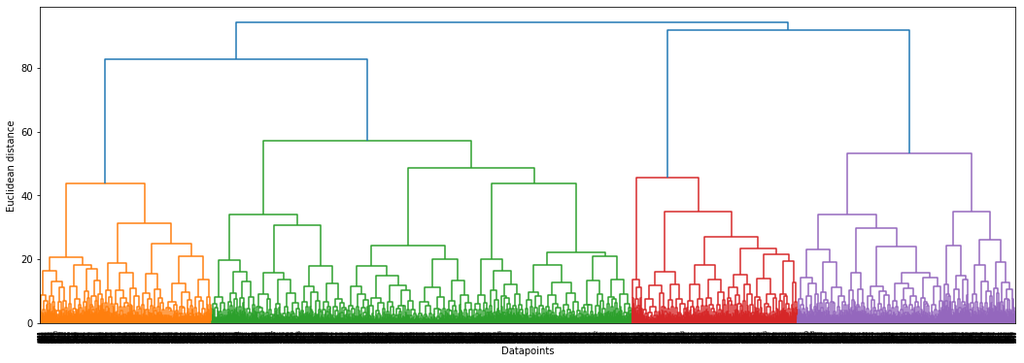

```python
# Drawing the dendrogram for Agglomerative clustering
plt.figure(figsize=[18,6])
merge = linkage(df2, method='ward')
dendrogram(merge, leaf_rotation = 90)
plt.xlabel('Datapoints')
plt.ylabel('Euclidean distance')
plt.show()
```

### b. Build a Agglomerative clustering model using the obtained optimal K value observed from dendrogram.

```python
## Building hierarchical clustering model using the optimal clusters as 4
hie_cluster = AgglomerativeClustering(n_clusters=4, affinity='euclidean',
                                     linkage='ward')
hie_cluster_model = hie_cluster.fit(df2)
```

```python
## Creating a dataframe of the labels
df_label1 = pd.DataFrame(hie_cluster_model.labels_,columns=['Labels'])
df_label1.head(5)
```

|  | Labels |
| --- | --- |
| 0 | 3 |
| 1 | 0 |
| 2 | 0 |
| 3 | 2 |
| 4 | 0 |

```python
# Joining the label dataframe with unscaled initial cleaned dataframe. (i.e. df_cleaned)
df_hier = df_cleaned.join(df_label1)
df_hier.head()
```

|  | fit | bust size | weight (in lbs) | rating | rented for | body type | category | height (in inches) | size | age | Labels |
| --- | --- | --- | --- | --- | --- | --- | --- | --- | --- | --- | --- |
| 0 | fit | 34d | 137.0 | 10.0 | vacation | hourglass | romper | 68.0 | 14 | 28.0 | 3.0 |
| 1 | fit | 34b | 132.0 | 10.0 | other | straight & narrow | gown | 66.0 | 12 | 36.0 | 0.0 |
| 3 | fit | 34c | 135.0 | 8.0 | formal affair | pear | dress | 65.0 | 8 | 34.0 | 2.0 |
| 4 | fit | 34b | 145.0 | 10.0 | wedding | athletic | gown | 69.0 | 12 | 27.0 | 0.0 |
| 5 | fit | 32b | 138.0 | 8.0 | date | athletic | dress | 68.0 | 8 | 45.0 | 0.0 |

### c. Compute silhouette score for evaluating the quality of the Agglomerative clustering technique. (Hint: Take a sample of the dataset for agglomerative clustering to reduce the computational time)

```python
for i in range(2,15):
    hier = AgglomerativeClustering(n_clusters=i)
    hier = hier.fit(df2)
    labels = hier.fit_predict(df2)
    print(i,silhouette_score(df2,labels))
```

```
2 0.10596947830186028
3 0.11208921858392236
4 0.11265768073941083
5 0.06409457844924754
6 0.07254276489615602
7 0.04934046809807843
8 0.0527712196185887
9 0.05819176417567287
10 0.05474221813068482
11 0.0455199594918867
12 0.048192625674926055
13 0.05072246139609499
14 0.050119796234222906
```

### Inference:

- From the silhouette score analysis of the Agglomerative clustering technique, we observe that the silhouette score is highest when the number of clusters (K) is set to 4.
- This finding aligns with the optimal K value determined from the dendrogram, further confirming that 4 clusters are suitable for this dataset. Therefore, based on both analyses, we can confidently conclude that 4 clusters provide the best segmentation of the data for this particular problem.

**Note:** It's important to consider that the analysis was conducted on a smaller sample of 5000 records from the dataset to expedite computation time. While this approach facilitates faster analysis, it's essential to recognize that the findings may vary slightly if applied to the entire dataset. Thus, the optimal number of clusters determined through silhouette score analysis should be interpreted within the context of using a sample and may not fully capture the characteristics of the entire dataset.

# ● Conclusion :

### 17.) Perform cluster analysis by doing bivariate analysis between cluster labels and different features and write your conclusion on the results.

```python
# Checking few records from the df_hier
df_hier.head()
```

|  | fit | bust size | weight (in lbs) | rating | rented for | body type | category | height (in inches) | size | age | Labels |
| --- | --- | --- | --- | --- | --- | --- | --- | --- | --- | --- | --- |
| 0 | fit | 34d | 137.0 | 10.0 | vacation | hourglass | romper | 68.0 | 14 | 28.0 | 3.0 |
| 1 | fit | 34b | 132.0 | 10.0 | other | straight & narrow | gown | 66.0 | 12 | 36.0 | 0.0 |
| 3 | fit | 34c | 135.0 | 8.0 | formal affair | pear | dress | 65.0 | 8 | 34.0 | 2.0 |
| 4 | fit | 34b | 145.0 | 10.0 | wedding | athletic | gown | 69.0 | 12 | 27.0 | 0.0 |
| 5 | fit | 32b | 138.0 | 8.0 | date | athletic | dress | 68.0 | 8 | 45.0 | 0.0 |

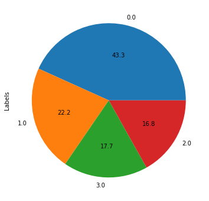

```python
plt.figure(figsize=(6, 6))
df_hier['Labels'].value_counts().plot(kind='pie', autopct='%0.1f')
plt.show()
```

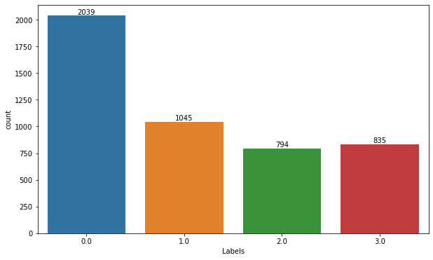

```python
plt.figure(figsize=(10, 6))
sns.countplot(x='Labels', data=df_hier)

# Adding count scores above each bar
for i in range(len(df_hier['Labels'].value_counts())):
    plt.text(i, df_hier['Labels'].value_counts()[i], df_hier['Labels'].value_counts()[i],
             ha='center', va='bottom')
plt.show()
```

#### Inference:

- The pie chart and count plot provide insights into the distribution of cluster labels in the dataset. Label '0.0' comprises the largest proportion at 43.3% and corresponds to 2039 records, followed by label '1.0' with 22.2% and 1045 records. Labels '3.0' and '2.0' represent 17.7% and 16.8%, respectively, amounting to 835 and 794 records each. This analysis reveals that label '0.0' is the most prevalent cluster, with the other labels decreasing in frequency.

#### Bivariate analysis for categorical features:

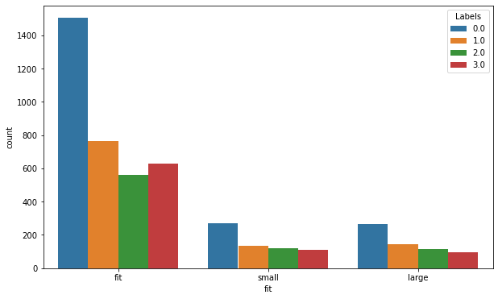

```python
# fit
plt.figure(figsize=(10, 6))
sns.countplot(df_hier['fit'],hue='Labels',data=df_hier)
plt.show()
```

#### Inference:

- The 'fit' status dominates among users, with relatively fewer opting for 'small' or 'large' sizes. Cluster 0 shows a higher concentration of customers across all 'fit' statuses compared to other clusters.

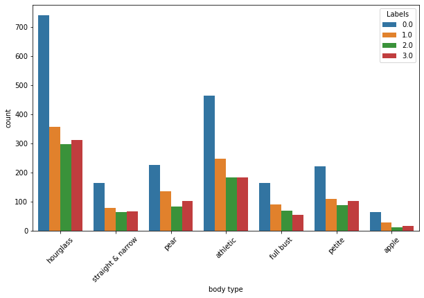

```python
# body type
plt.figure(figsize=(10, 6))
sns.countplot(df_hier['body type'],hue='Labels',data=df_hier)
plt.xticks(rotation = 45)
plt.show()
```

#### Inference:

- There is a notable prevalence of customers with an 'hourglass' body type, followed by 'athletic', while 'apple' body types are relatively less common. Additionally, cluster 0 exhibits a higher proportion of customers across all body types compared to other clusters.

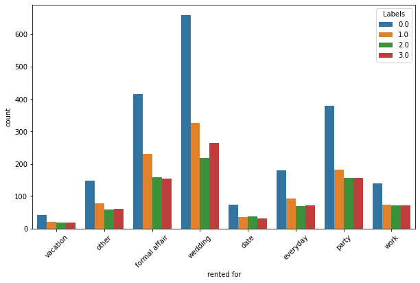

```python
# rented for
plt.figure(figsize=(10, 6))
sns.countplot(df_hier['rented for'],hue='Labels',data=df_hier)
plt.xticks(rotation = 45)
plt.show()
```

#### Inference:

- The majority of customers have rented products for 'wedding', indicating a prevalent preference for such occasions. Moreover, cluster 0 encompasses a larger proportion of users compared to clusters 1, 2, and 3 across all rental purposes.

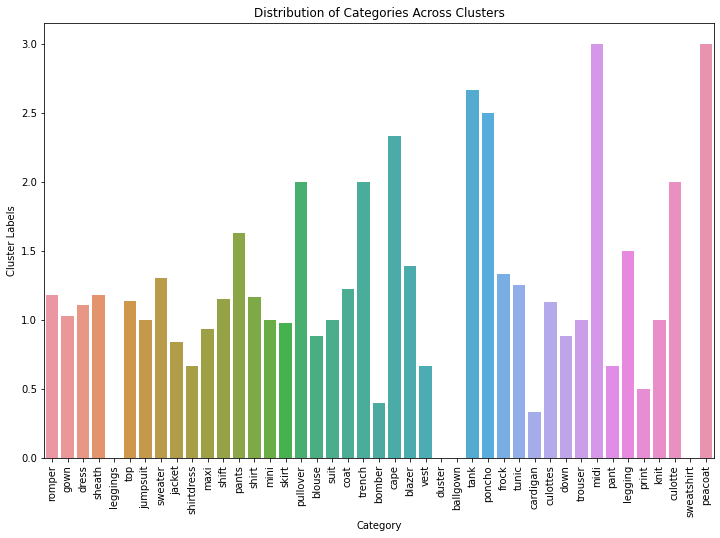

```python
# 'category'

# Drop rows with non-finite values in the 'Labels' column
df_hier.dropna(subset=['Labels'], inplace=True)

# Convert 'Labels' column to integer type
df_hier['Labels'] = df_hier['Labels'].astype(int)

plt.figure(figsize=(12, 8))
sns.barplot(x='category', y='Labels', data=df_hier, ci=None, hue_order=[0, 1, 2, 3])
plt.title('Distribution of Categories Across Clusters')
plt.xlabel('Category')
plt.ylabel('Cluster Labels')
plt.xticks(rotation=90)
plt.show()
```

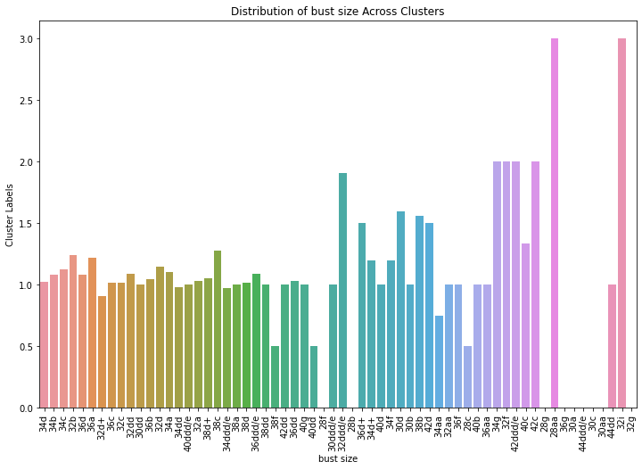

```python
# 'bust size'

# Drop rows with non-finite values in the 'Labels' column
df_hier.dropna(subset=['Labels'], inplace=True)

# Convert 'Labels' column to integer type
df_hier['Labels'] = df_hier['Labels'].astype(int)
plt.figure(figsize=(12, 8))
sns.barplot(x='bust size', y='Labels', data=df_hier, ci=None, hue_order=[0, 1, 2, 3])
plt.title('Distribution of bust size Across Clusters')
plt.xlabel('bust size')
plt.ylabel('Cluster Labels')
plt.xticks(rotation=90)
plt.show()
```

#### Inference:

- In the plot, when bars start from 0 for a cluster, it means that cluster has the least count for that category. Conversely, taller bars for a category in a cluster indicate higher interest compared to other clusters. By comparing bar lengths across clusters, we gauge relative category preferences.

#### Bivariate analysis for numerical features:

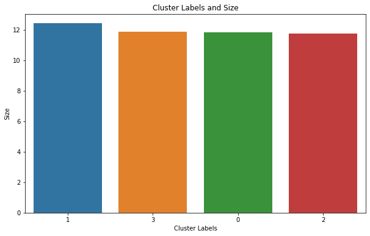

```python
# size
plt.figure(figsize=(10, 6))
sns.barplot(x='Labels', y='size', data=df_hier, estimator=np.mean, ci=None,
            order=df_hier.groupby('Labels')['size'].mean().sort_values(ascending=False).index)
plt.title('Cluster Labels and Size')
plt.xlabel('Cluster Labels')
plt.ylabel('Size')
plt.show()
```

#### Inference:

- From the bar plot displaying the mean size by cluster labels, it's evident that cluster 1 has the highest mean size compared to the other clusters, while the sizes across clusters 0, 2, and 3 are relatively similar. This suggests that cluster 1 may represent a segment of customers who prefer larger sizes compared to the rest of the clusters.

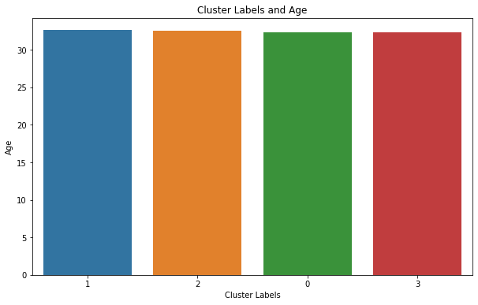

```python
# age
plt.figure(figsize=(10, 6))
sns.barplot(x='Labels', y='age', data=df_hier, estimator=np.mean, ci=None,
            order=df_hier.groupby('Labels')['age'].mean().sort_values(ascending=False).index)
plt.title('Cluster Labels and Age')
plt.xlabel('Cluster Labels')
plt.ylabel('Age')
plt.show()
```

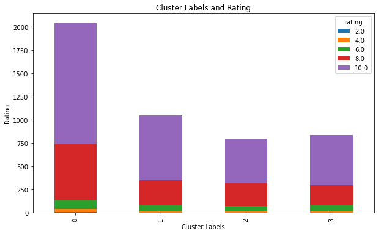

```python
# rating
pd.crosstab(df_hier['Labels'], df_hier['rating']).plot(kind='bar', stacked=True, figsize=(10, 6))
plt.title('Cluster Labels and Rating')
plt.xlabel('Cluster Labels')
plt.ylabel('Rating')
plt.show()
```

#### Inference:

- The stacked bar plot illustrates that products within cluster label 0 have the highest count of ratings rated as 10 compared to other clusters. This observation suggests that a significant portion of customers in cluster label 0 tends to rate their rented items with the highest rating (10).
- This could imply a high level of satisfaction or preference among customers in cluster label 0 for the rented products, potentially indicating successful product selection or service delivery targeting this customer segment.

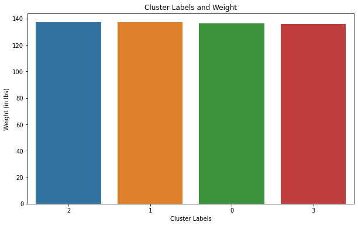

```python
plt.figure(figsize=(10, 6))
sns.barplot(x='Labels', y='weight (in lbs)', data=df_hier, estimator=np.mean, ci=None,
            order=df_hier.groupby('Labels')['weight (in lbs)'].mean().sort_values(ascending=False).index)
plt.title('Cluster Labels and Weight')
plt.xlabel('Cluster Labels')
plt.ylabel('Weight (in lbs)')
plt.show()
```

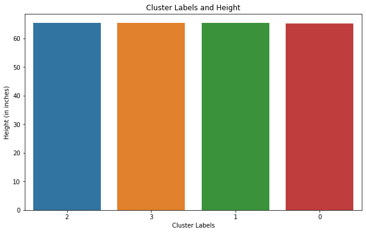

```python
# height (in inches)
plt.figure(figsize=(10, 6))
sns.barplot(x='Labels', y='height (in inches)', data=df_hier, estimator=np.mean, ci=None,
            order=df_hier.groupby('Labels')['height (in inches)'].mean().sort_values(ascending=False).index)
plt.title('Cluster Labels and Height')
plt.xlabel('Cluster Labels')
plt.ylabel('Height (in inches)')
plt.show()
```

#### Inference:

- The bar plot depicts the height (in inches) across different cluster labels. Despite the specified descending order, the bars appear nearly equal in length, indicating similar mean heights across clusters. The average height ranges around 65 inches across all clusters, suggesting consistent height distribution.

📝 Completed by **Shrikant Verma** 🚀